# SIMULATION DE CRISE ET IMPACTS SUR UN PORTEFEUILLE D’ACTIFS

# Données

Nous avons utlisé un portefeuille de 10 actifs pour un total de 100 actions avec les pondérations suivantes:

1. Air Liquide : 9,97%
2. Total : 18,40%
3. Axa: 12,05%
4. Bnp Paribas : 22,63%
5. Société Générale : 1,85%
6. Vinci : 9,79%
7. Compagnie Saint Gobin : 1,92%
8. LMVH : 2,87%
9. Orange : 3,48%
10. Crédit Agricole : 17,03%

Données : Cours moyen journalier de l’action entre 01/01/2010 et 31/12/2015. (yahoo finance)

# Evolution du cours historique du portefeuille

[interactive chart not shown]

# Evolution du Rendement historique du portefeuille d’actif

[interactive chart not shown]

# Ratio de sharpe annualisé et MaxDrowDown

```
## Le MaxDrowDown:  0.4744447
```

```
## Le Ratio de sharpe annualisé:  -3.311818
```

[output not shown]

# Matrice des corrélations

- Il existe une forte dépendance entre les rendements des actifs du portefeuille.

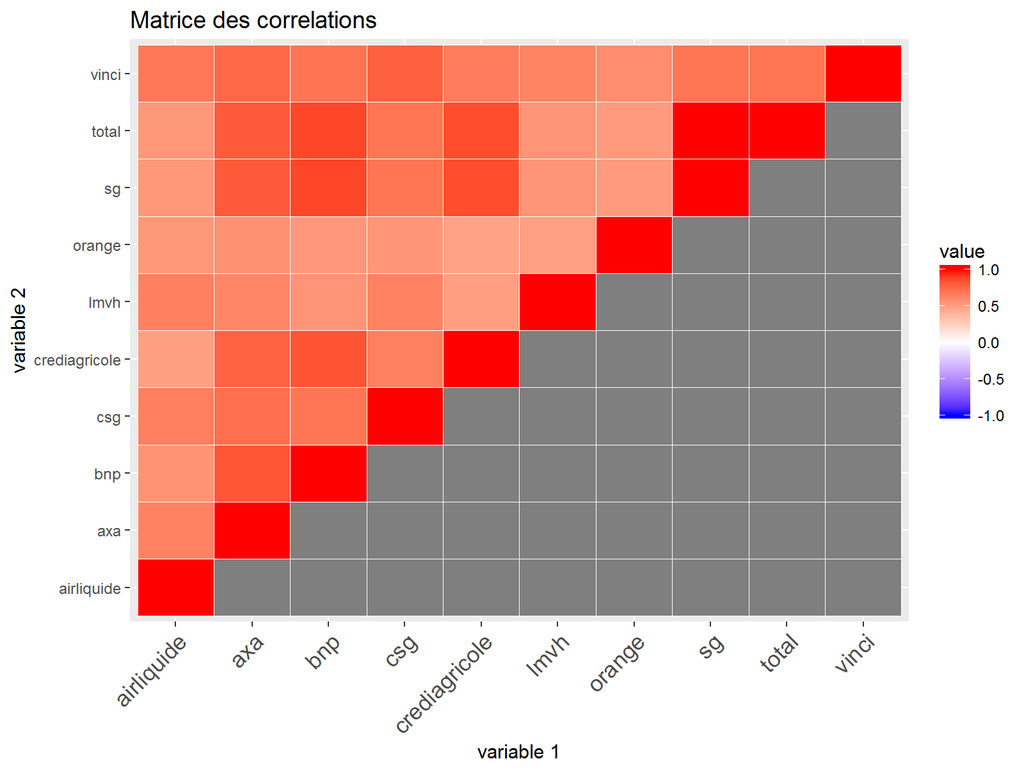

# Matrice des covariances

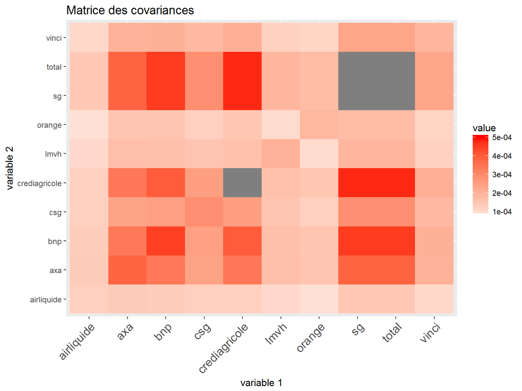

# Test de normalité des rendements

- Les rendements historiques journaliers ne suivent pas une loi normale.
- Pour but de simplification nous supposons le contraire.

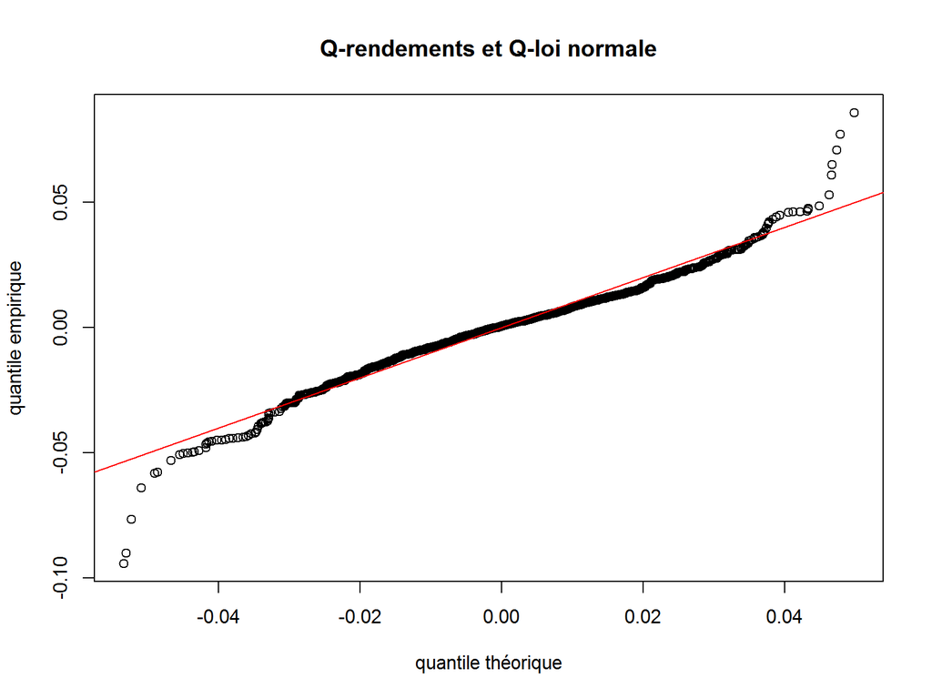

```
##
##  Shapiro-Wilk normality test
##
## data:  (as.data.frame(rendement_histo_port))$portfolio.returns
## W = 0.95963, p-value < 2.2e-16
```

```
##
##  Jarque Bera Test
##
## data:  (as.data.frame(rendement_histo_port))$portfolio.returns
## X-squared = 1077.8, df = 2, p-value < 2.2e-16
```

# VaR à 99% et CTE

```
## VaR historique à 99% :  -0.0445932
```

```
## VaR théorique à 99% de la loi normale:  -0.0362704
```

```
## CTE à partir de la VaR historique à 99%:  -0.05577177
```

# Simulation : Projection du portefeuille sur un an.

Qu’est ce que l’avenir réserve à ce portefeuille ?

- Projection du portefeuille du 01/01/2016 au 31/12/2016
- Modèle de projection utilisé : Black and Scholes. (wikipedia)

$$S_{t}=S_{0}exp{(\sigma W_{t}+\mu t)}$$
$$S_{t}:\: prix\: du\: portefeuille\: à\: t$$
$$S_{0} : prix\: au\: 31/12/2015$$
$$\sigma : volatilité$$
$$W_{t} : Mouvement\: brownien\: standard$$
$$\mu : rendement$$
$$t : temps\: t=0 \leq t \leq T=1$$
- Nous supposons que le portefeuille ne paie pas de dividende.

- Estimation des paramètres par les moments d’ordre 1 et 2.

# Simulation : Mouvement Brownien standard

[figure not shown]

# Simulation : Rendements simulées

[interactive chart not shown]

# Simulation : Evolution des VaR

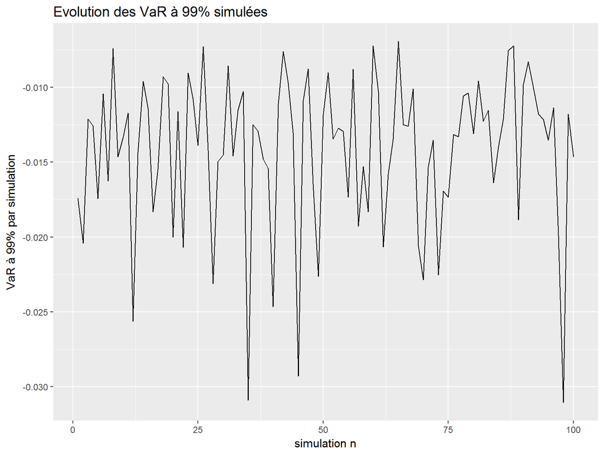

```
## VaR minimale à 99%, de toute les simulations:  -0.03108252
```

```
## VaR moyenne à 99%, de toute les simulations:  -0.01414907
```

```
## VaR historique à 99% :  -0.0445932
```

# Simulation : Volatilités observées

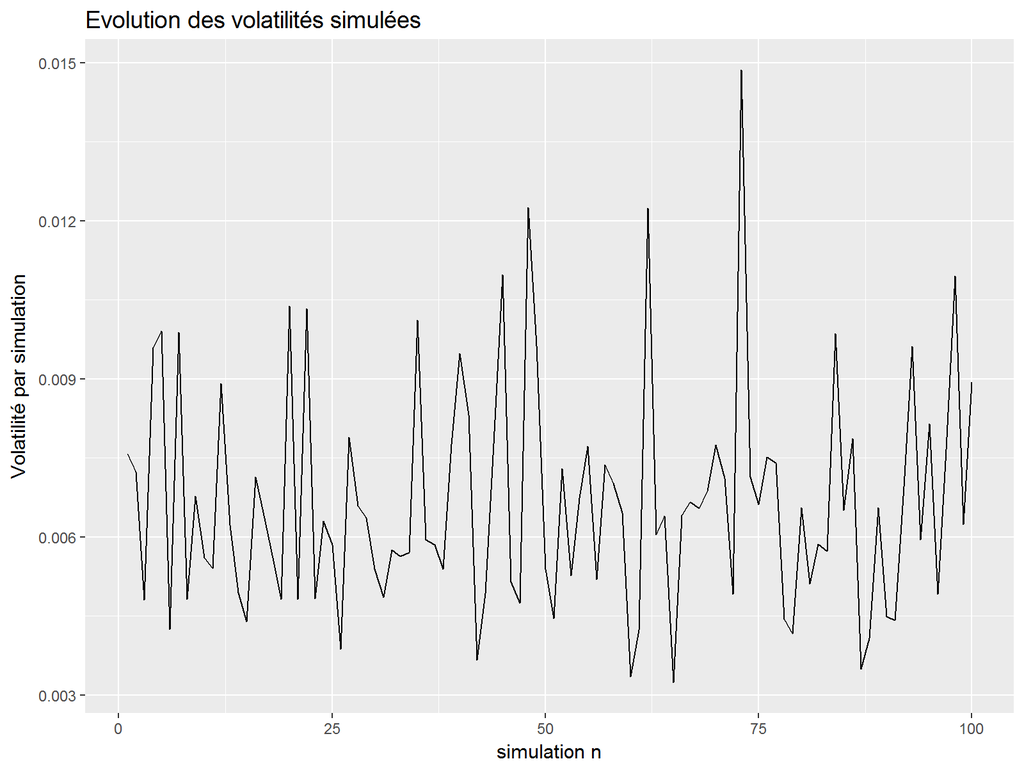

```
## Volatilité maximale observée , de toute les simulations (avant crise):  0.01486252
```

```
## Volatilité moyenne observée , de toute les simulations (avant crise):  0.006680352
```

# Simulation de crise : Scénario extrême

Pour la simulation de crise nous partons du scénario imaginatif suivant :

- Baisse du rendement moyen de 80%
- Augmentation de la volatilité de 100%

Nous ne tenons pas compte de la probabilité de survenance de crise.

# Simulation de crise : VaR stressée

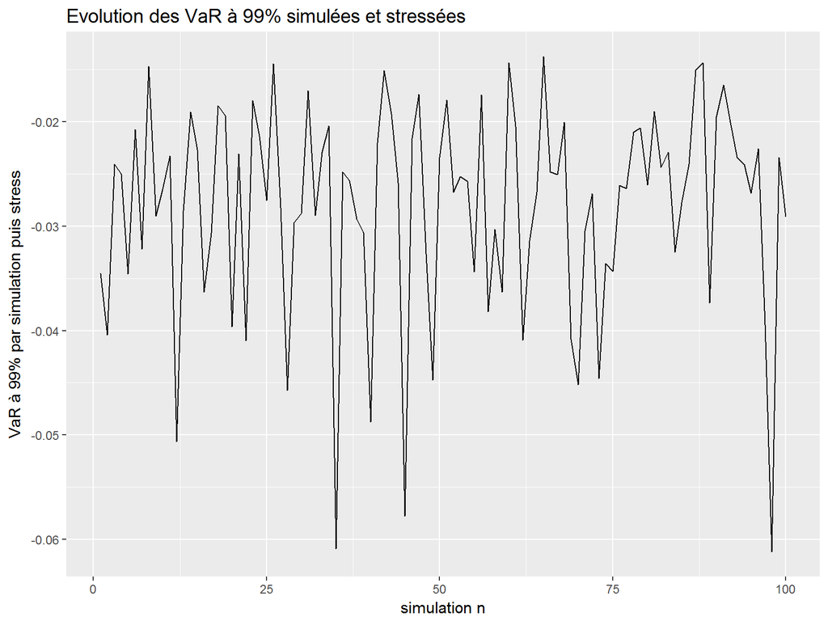

```
## VaR minimale à 99% de toutes simulations (stressée):  -0.06
```

```
## VaR minimale à 99%, de toute les simulations:  -0.03108252
```

```
## VaR moyenne de toutes simulations (stressée):  -0.0279
```

```
## VaR moyenne à 99%, de toute les simulations:  -0.01414907
```

```
## VaR historique à 99% :  -0.0445932
```

# Volatilités en simulation de crise

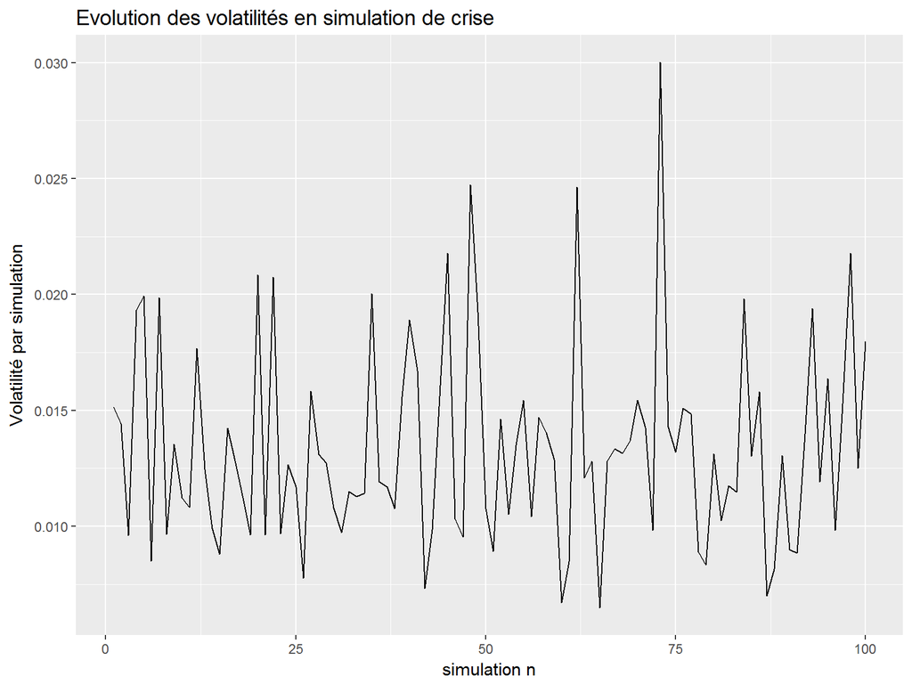

```
## Volatilité maximale observée après simulation de crise:  0.03001859
```

```
## Volatilité maximale observée , de toute les simulations (avant crise):  0.01486252
```

[output not shown]

```
## Volatilité moyenne observée , de toute les simulations (avant crise):  0.006680352
```

# Conclusion

1. Nous avons projeté le portefeuille sur un an puis en avons calculé la VaR.
2. Nous avons imaginé puis impacté les paramètres de projection du portefeuille et avons calculé à nouveau la VaR dite stressée.
3. On en déduit la VaR en situation sans crise et la VaR si toutefois une crise se produit sur les marchés financiers.
4. Nous observons ensuite des indicateurs de risque de marché avant et après crise : VaR et Volatilité.
5. Nous avons posé un ensemble d’hypothèse à des buts de simplification.
6. l’estimation des paramètres et les modèles de VaR peuvent être très complexes.
7. La simulation de crise pour le risque de marché permet d’estimer la perte qui pourrait survenir si un scénario extrême se produisait sur les marchés financiers.
8. Les entreprises peuvent donc estimer leur résistance et mettre en place les processus de gestion de risque adéquats.